# Bike-Share Navigate Speedy Success?

# 6 Conclusion: Share Data Findings and Recommendations

Cyclistic bike use is popular during the summer months and decrease during fall and winter months for both casual and annual members.

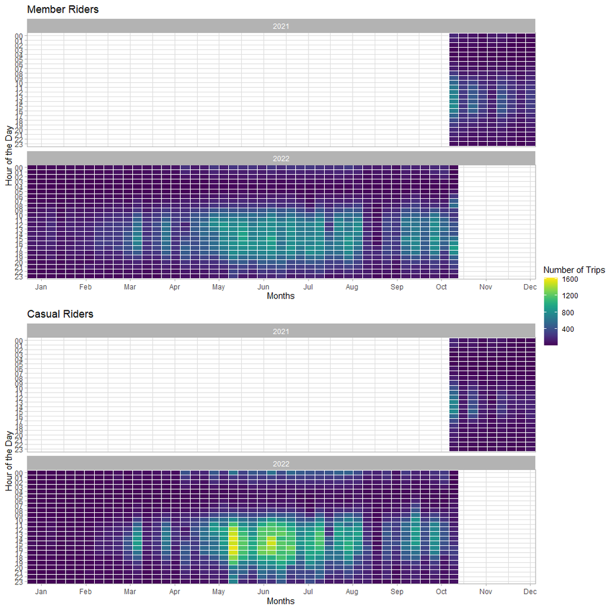

Casual members use Cyclistic bikes predominantly during the summer months peaking during the last week of May from 11:00:00 to 16:00:00. Compared to casual members, annual members has a relatively steady amount of rider usage throughout the summer months during May through August.Annual members tend to be most active during the beginning of the week peaking on Wednesday at totaling at 388,275 trips. Inversely casual riders are most active during Saturday at 350,037 rides.

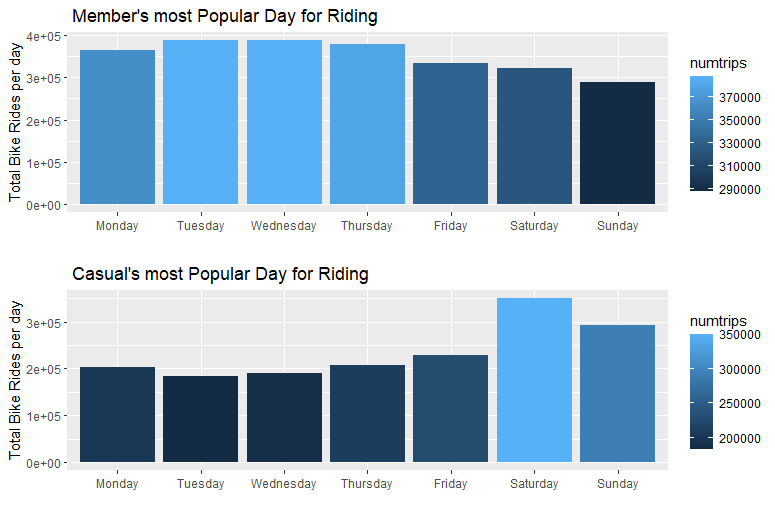

Annual members use Cyclistic bike more than casual members. Inversely casual member ride length is higher then annual members. This may be ue to causal member using Cyclistic bike for leisurely activity for longer period of time compared to members using the service for short commutes or running errands. Ride length is longer for the classic bike followed by electric and docked bikes with casual member . Annual members do not use dock bikes at all and prefer classic bike or electric bikes.

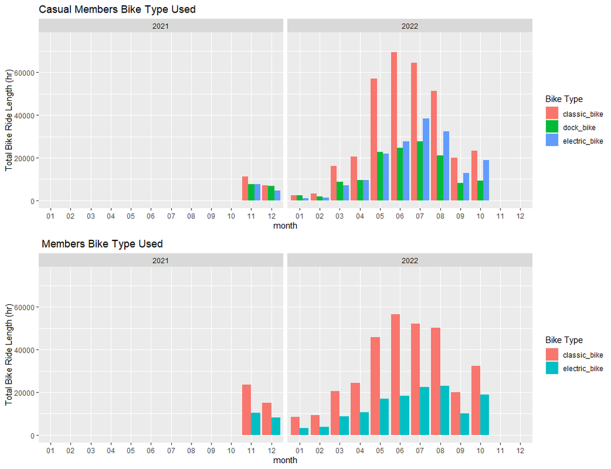

• Cyclistic bike use is very popular for casual and annual members around the “Loop” area of the city of Chicago, a prime business and tourist location.

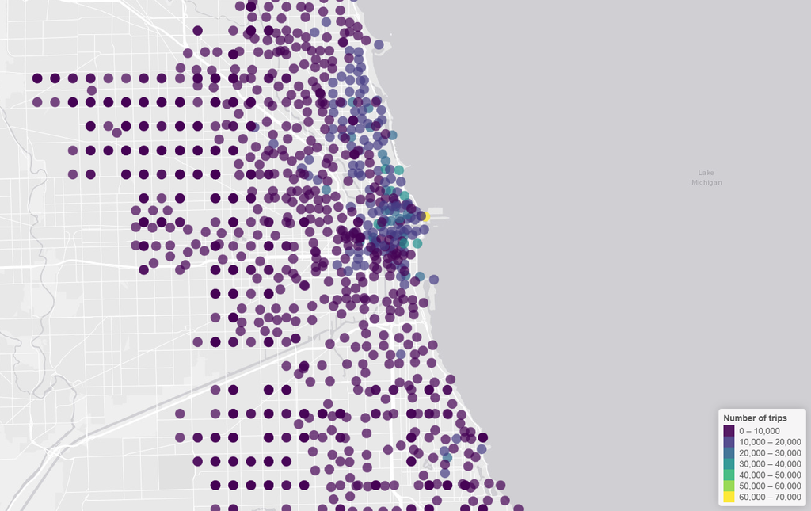

• Top 100 bike stations

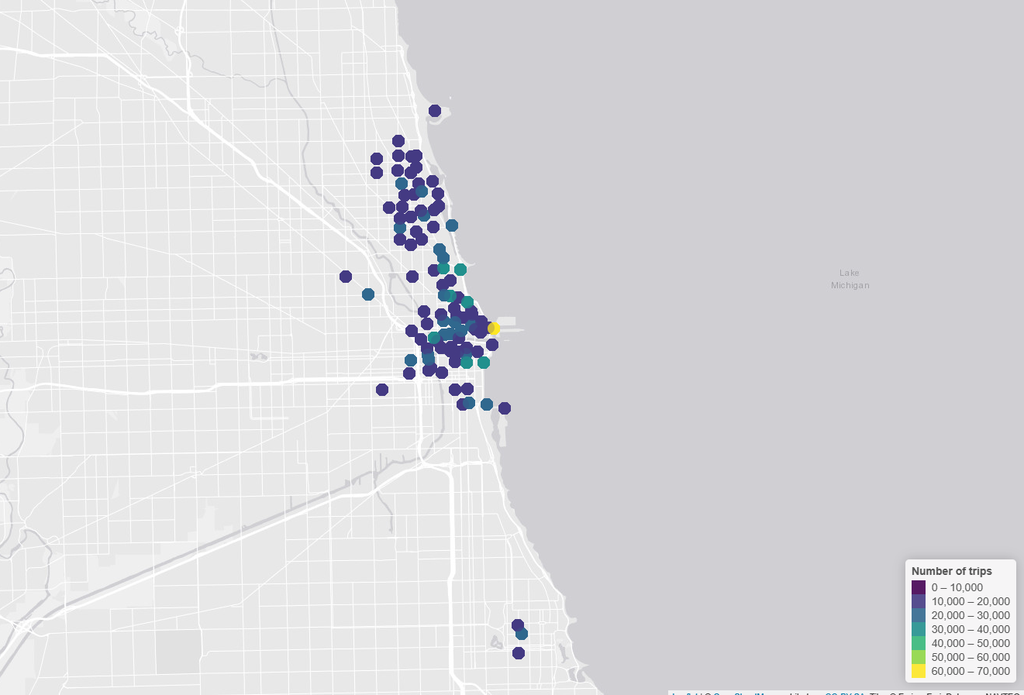

• Top 10 stations are:

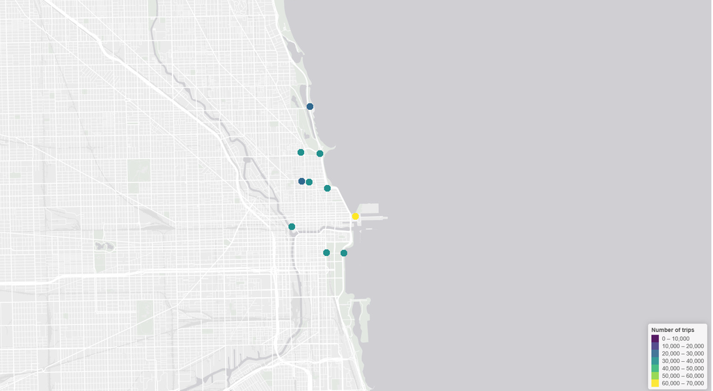

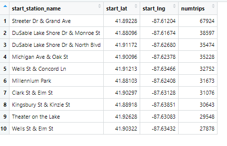

Casual riders out number annual members around the area due to the high tourist attraction and parks, reflecting bike use for leisurely activity. In contrast, Annual members bike rides reflect the act of commuting for work or business activity. 2nd popular area for Cyclistic bike use is north of the Loop around Wrigley Field.

#### 6.1 How could your team and business apply your insights?

• Any promotions should be done on Saturday during peak hours of 1200 to 1600 hr. Specifically summer months late May through August to maximize the promotional message to casual bike share riders.

#### 6.2 What next steps would you or your stakeholders take based on your ﬁndings?

Promotional campaign focused on casual riders. Communicate to casual riders that there could be incentives to becoming from annual member. * 1 month free or discounted price for 12 months subscription * Communicate to casual member who reach a ride length thrush hold that it may be beneficial economically to convert to annual

Limitations of the analysis- Cost to use Cyclistic bike share is not included in the data set. Or the total amount of money spent per month to use Cyclistic ride length for each bike user. This could greatly increase the amount of possible promotional ideas to be presented that may be effective in converting causal members to annual members.